# Supervised Learning - Classification 01

# Pengaruh "ketinggian" tree terhadap bentuk model

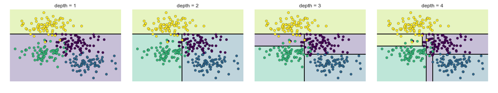

## Teori Decision Tree : Information theory

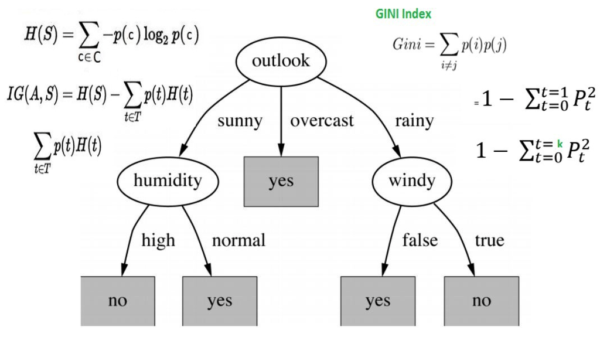

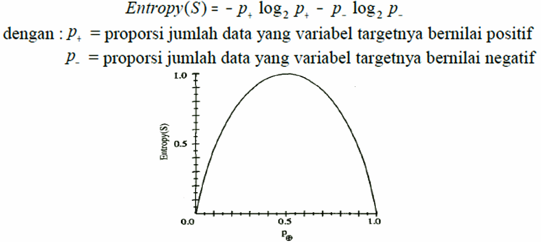

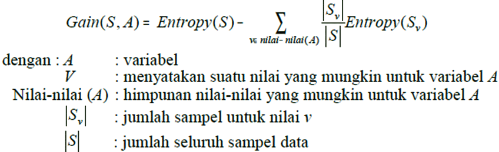

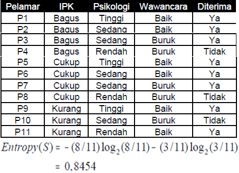

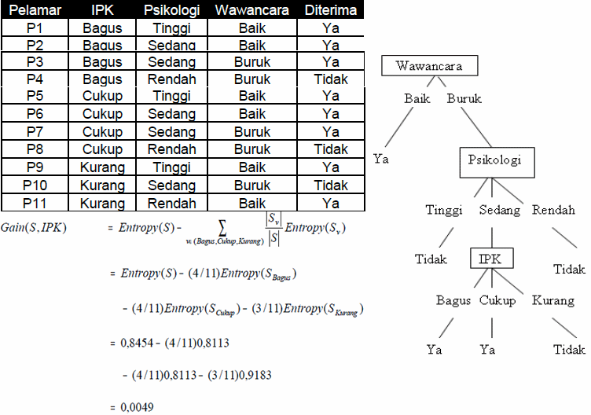

- Contoh Lain: http://www.saedsayad.com/decision_tree.htm

## Alternative to Information Gain : Gini Index (CART)

https://medium.com/deep-math-machine-learning-ai/chapter-4-decision-trees-algorithms-b93975f7a1f1

**When to use:**

- Target : Binomial/nominal.
- Predictors (input): binomial, nominal, and-or interval (ratio).

**Advantage:**

- Fast and embarrassingly parallel.
- Tanpa iterasi, cocok untuk Big Data technology (e.g. Hadoop)[map-reduce friendly]
- Interpretability
- Robust terhadap outliers & missing values

**Disadvantage:**

- Non probabilistic (ad hoc heuristic) +/-
- Target dengan banyak kelas
- Sensitive (instability)

```python
# Decision Tree: http://scikit-learn.org/stable/modules/tree.html
from sklearn import tree

DT = tree.DecisionTreeClassifier()
DT = DT.fit(X_train, y_train)
y_DT = DT.predict(X_test)
print(accuracy_score(y_test, y_DT))
print(confusion_matrix(y_test, y_DT))
print(classification_report(y_test, y_DT))
```

```
0.9298245614035088
[[ 90   9]
 [ 11 175]]
              precision    recall  f1-score   support

           0       0.89      0.91      0.90        99
           1       0.95      0.94      0.95       186

    accuracy                           0.93       285
   macro avg       0.92      0.92      0.92       285
weighted avg       0.93      0.93      0.93       285
```

```python
# Load ulang Data
df = sns.load_dataset("iris")
df.sample(7)
```

|  | sepal_length | sepal_width | petal_length | petal_width | species |
| --- | --- | --- | --- | --- | --- |
| 99 | 5.7 | 2.8 | 4.1 | 1.3 | versicolor |
| 33 | 5.5 | 4.2 | 1.4 | 0.2 | setosa |
| 7 | 5.0 | 3.4 | 1.5 | 0.2 | setosa |
| 119 | 6.0 | 2.2 | 5.0 | 1.5 | virginica |
| 74 | 6.4 | 2.9 | 4.3 | 1.3 | versicolor |
| 39 | 5.1 | 3.4 | 1.5 | 0.2 | setosa |
| 43 | 5.0 | 3.5 | 1.6 | 0.6 | setosa |

```python
# Separate Data
X = df[['sepal_length','sepal_width','petal_length','petal_width']]
Y = df['species']
seed = 9
validation_size = 0.3
X_train, X_test, Y_train, Y_test = train_test_split(X, Y, test_size=validation_size, random_state=seed)
print(X_train.shape, len(Y_test))
```

```
(105, 4) 45
```

```python
# Build the model and Evaluate
dt_model = tree.DecisionTreeClassifier(criterion='entropy', max_depth=3, random_state=seed) # Default Gini
dt = dt_model.fit(X_train, Y_train)
dt_prediction = dt.predict(X_test)
print('Akurasi = ', accuracy_score(Y_test, dt_prediction))
print(confusion_matrix(Y_test, dt_prediction))
print(classification_report(Y_test, dt_prediction))
```

```
Akurasi =  0.9777777777777777
[[18  0  0]
 [ 0 14  0]
 [ 0  1 12]]
              precision    recall  f1-score   support

      setosa       1.00      1.00      1.00        18
  versicolor       0.93      1.00      0.97        14
   virginica       1.00      0.92      0.96        13

    accuracy                           0.98        45
   macro avg       0.98      0.97      0.98        45
weighted avg       0.98      0.98      0.98        45
```

```python
# Varible importance - Salah satu kelebihan Decision Tree
dt.feature_importances_
```

```
array([0.        , 0.        , 0.70559151, 0.29440849])
```

```python
# Kelebihan lain Decision Tree yang tidak dimiliki model lain

# "WARNING"
# 1. tidak bisa dijalankan di Google Colab
# 2. membutuhkan software "graphViz" + setting system variabel
# caranya ada disini: https://stackoverflow.com/questions/49471867/installing-graphviz-for-use-with-python-3-on-windows-10
# installernya ada di Folder "UIN Bandung" yang diawal di copy dari flashDisk

import graphviz

dot_data = tree.export_graphviz(dt, out_file=None)
graph = graphviz.Source(dot_data)
graph.render("iris")
var_names = ['sepal_length','sepal_width','petal_length','petal_width']
categories = ['Setosa', 'VersiColor', 'Virginica']
dot_data = tree.export_graphviz(dt, out_file=None,
                         feature_names = var_names,
                         class_names=categories,
                         filled=True, rounded=True,
                         special_characters=True)
graph = graphviz.Source(dot_data)
graph
```

[figure not shown]

## Naive Bayes Classifier

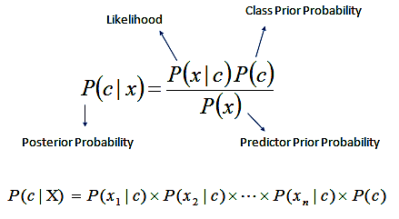

- P(x) konstan, sehingga bisa diabaikan.
- Asumsi terkuatnya adalah independensi antar variabel prediktor (sehingga dikatakan "Naive")
- Klasifikasi dilakukan dengan menghitung probabilitas untuk setiap kategori ketika diberikan data x = (x1,x2,...,xm)
- Untuk data yang besar bisa menggunakan out-of-core approach (partial fit):  
  http://scikit-learn.org/stable/modules/scaling_strategies.html#scaling-strategies
- Variasi NBC adalah bagaimana P(c|x) dihitung, misal dengan distribusi Gaussian (Normal) - sering disebut sebagai Gaussian Naive Bayes (GNB):

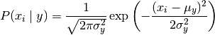

**Pros:**

- Cepat dan mudah di implementasikan
- Cocok untuk permasalahan multiclass
- Jika asumsi terpenuhi (independent) biasanya performanya cukup baik dan membutuhkan data (training) yang lebih sedikit.
- Biasanya baik digunakan untuk prediktor kategorik, untuk numerik NBC mengasumsikan distribusi normal (terkadang tidak terpenuhi)

**Cons:**

- Jika di test data memuat kategori yang tidak ada di training data ( ==> probabilitas = 0). Sering disebut sebagai masalah “Zero Frequency”.
- Asumsi yang sangat kuat (independen antar prediktor).

# Aplikasi di Python

```python
# Naive Bayes: http://scikit-learn.org/stable/modules/naive_bayes.html
from sklearn.naive_bayes import GaussianNB

gnb = GaussianNB()
nbc = gnb.fit(X_train, Y_train)
nbc_prediction = nbc.predict(X_test)

print('Akurasi = ', accuracy_score(Y_test, nbc_prediction))
print(confusion_matrix(Y_test, nbc_prediction))
print(classification_report(Y_test, nbc_prediction))
```

```
Akurasi =  1.0
[[18  0  0]
 [ 0 14  0]
 [ 0  0 13]]
              precision    recall  f1-score   support

      setosa       1.00      1.00      1.00        18
  versicolor       1.00      1.00      1.00        14
   virginica       1.00      1.00      1.00        13

    accuracy                           1.00        45
   macro avg       1.00      1.00      1.00        45
weighted avg       1.00      1.00      1.00        45
```

# Membandingkan model-model yang sudah kita bahas sejauh ini

- Code-nya bisa dimodifikasi sedikit untuk perbandingan model yang lain atau data yang lain

```python
# Model Comparisons using Cross Validation
X = df[['sepal_length','sepal_width','petal_length','petal_width']]
Y = df['species']

Models = [('Regresi Logistik',clf), ('k-NN',kNN),('Naive Bayes',gnb), ('Decision Tree',DT)]
Scores = {}
for model_name, model in Models:
    if model_name=='Naive Bayes':
        Scores[model_name] = cross_val_score(model, X.values, Y, cv=10,scoring='accuracy')
    else:
        Scores[model_name] = cross_val_score(model, X, Y, cv=10,scoring='accuracy')

dt = pd.DataFrame.from_dict(Scores)
dt.head()
```

|  | Regresi Logistik | k-NN | Naive Bayes | Decision Tree |
| --- | --- | --- | --- | --- |
| 0 | 0.933333 | 1.000000 | 0.933333 | 1.000000 |
| 1 | 0.866667 | 0.933333 | 0.933333 | 0.933333 |
| 2 | 1.000000 | 1.000000 | 1.000000 | 1.000000 |
| 3 | 0.933333 | 0.933333 | 0.933333 | 0.933333 |
| 4 | 0.933333 | 0.866667 | 0.933333 | 0.933333 |

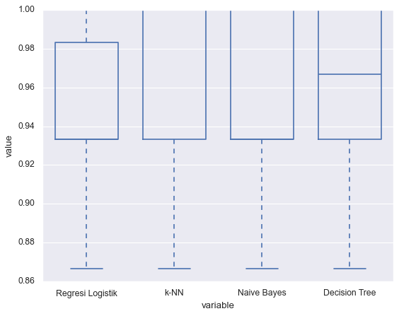

```python
p = sns.boxplot(data=dt.melt(value_vars=['Regresi Logistik','k-NN', 'Naive Bayes', 'Decision Tree']), x='variable', y='value', fill=False, gap=.1)
plt.show()
```

# End of Module

[figure not shown]